# individual2

Jaeyeon Won

9/24/2020

## Reading in the Data Set

```r
# libraries
library(readxl)
library(ggplot2)
library(tidyverse)
# Reading in the data set
happiness <- readxl::read_xls('JaeyeonWon_GSS.xls')

# Structure
str(happiness)
```

```
## tibble [64,814 x 9] (S3: tbl_df/tbl/data.frame)
##  $ Gss year for this respondent    : num [1:64814] 1972 1972 1972 1972 1972 ...
##  $ Respondent id number            : num [1:64814] 1 2 3 4 5 6 7 8 9 10 ...
##  $ Marital status                  : chr [1:64814] "Never married" "Married" "Married" "Married" ...
##  $ Age of respondent               : chr [1:64814] "23" "70" "48" "27" ...
##  $ Highest year of school completed: chr [1:64814] "16" "10" "12" "17" ...
##  $ Respondents sex                 : chr [1:64814] "Female" "Male" "Female" "Female" ...
##  $ Total family income             : chr [1:64814] "Not applicable" "Not applicable" "Not applicable" "Not applicable" ...
##  $ Political party affiliation     : chr [1:64814] "Ind,near dem" "Not str democrat" "Independent" "Not str democrat" ...
##  $ General happiness               : chr [1:64814] "Not too happy" "Not too happy" "Pretty happy" "Not too happy" ...
```

## Exploration

**Use ggplot2 to create the plots, and dplyr to manipulate the data frame as much as possible. You may want to rename the columns of the data frame for your convenience using rename in dplyr.**

```r
# Renaming
names(happiness)
```

```
## [1] "Gss year for this respondent"     "Respondent id number"
## [3] "Marital status"                   "Age of respondent"
## [5] "Highest year of school completed" "Respondents sex"
## [7] "Total family income"              "Political party affiliation"
## [9] "General happiness"
```

```r
happiness = happiness %>%
  rename(year = 'Gss year for this respondent',
         id = 'Respondent id number',
         married = 'Marital status',
         age = 'Age of respondent',
         edu = 'Highest year of school completed',
         gender = 'Respondents sex',
         income = 'Total family income',
         party = 'Political party affiliation',
         happiness = 'General happiness')
names(happiness)
```

```
## [1] "year"      "id"        "married"   "age"       "edu"       "gender"
## [7] "income"    "party"     "happiness"
```

**1. Find the average years of education for the respondents with each political party affiliation. Arrange your output in a meaningful order and print. Describe any patterns you find.**

```r
# edu
happiness$edu = as.factor(happiness$edu)
levels(happiness$edu)
```

```
##  [1] "0"          "1"          "10"         "11"         "12"
##  [6] "13"         "14"         "15"         "16"         "17"
## [11] "18"         "19"         "2"          "20"         "3"
## [16] "4"          "5"          "6"          "7"          "8"
## [21] "9"          "Don't know" "No answer"
```

```r
# party
happiness$party = as.factor(happiness$party)
levels(happiness$party)
```

```
##  [1] "Don't know"         "Ind,near dem"       "Ind,near rep"
##  [4] "Independent"        "No answer"          "Not str democrat"
##  [7] "Not str republican" "Other party"        "Strong democrat"
## [10] "Strong republican"
```

```r
# Numerical summary of average years of education for each political party affiliation
`%notin%` = Negate(`%in%`)

happiness1 = happiness %>%
  filter(edu %notin% c("No answer", "Don't know")) %>%
  group_by(party) %>%
  summarise(mean_edu = mean(as.numeric(edu))) %>%
  arrange(desc(mean_edu))
happiness1
```

```
## # A tibble: 10 x 2
##    party              mean_edu
##    <fct>                 <dbl>
##  1 Don't know             9.09
##  2 Strong democrat        8.81
##  3 Other party            8.41
##  4 No answer              8.23
##  5 Not str democrat       8.20
##  6 Strong republican      8.17
##  7 Independent            8.05
##  8 Ind,near dem           7.93
##  9 Not str republican     7.92
## 10 Ind,near rep           7.78
```

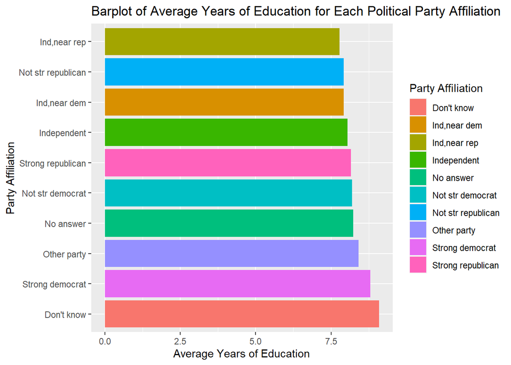

```r
# Graphical summary of average years of education for each political party affiliation
happiness1 %>%
  ggplot(aes(x = reorder(party, -mean_edu), weight = mean_edu, fill = party)) +
  geom_bar() +
  coord_flip() +
  ggtitle('Barplot of Average Years of Education for Each Political Party Affiliation') +
  xlab('Party Affiliation') +
  ylab('Average Years of Education') +
  labs(fill = "Party Affiliation")
```

**2. Create a single data frame containing records for the better educated respondents in each political party affiliation. A “better educated” respondent is someone who has strictly more years of education than the median in the same party affiliation. Print the structure of the data frame.**

```r
# Creating a data frame
happiness2 = happiness %>%
  filter(edu %notin% c("No answer", "Don't know")) %>%
  group_by(party) %>%
  mutate(median_edu = median(as.numeric(edu))) %>%
  filter(as.numeric(edu) > median_edu) %>%
  ungroup()

# Structure of data frame
str(happiness2)
```

```
## tibble [28,143 x 10] (S3: tbl_df/tbl/data.frame)
##  $ year      : num [1:28143] 1972 1972 1972 1972 1972 ...
##  $ id        : num [1:28143] 1 4 8 12 13 14 15 18 19 25 ...
##  $ married   : chr [1:28143] "Never married" "Married" "Never married" "Married" ...
##  $ age       : chr [1:28143] "23" "27" "27" "56" ...
##  $ edu       : Factor w/ 23 levels "0","1","10","11",..: 9 10 9 18 21 20 21 20 10 9 ...
##  $ gender    : chr [1:28143] "Female" "Female" "Male" "Male" ...
##  $ income    : chr [1:28143] "Not applicable" "Not applicable" "Not applicable" "Not applicable" ...
##  $ party     : Factor w/ 10 levels "Don't know","Ind,near dem",..: 2 6 2 7 9 6 9 3 2 10 ...
##  $ happiness : chr [1:28143] "Not too happy" "Not too happy" "Not too happy" "Pretty happy" ...
##  $ median_edu: num [1:28143] 7 6 7 7 7 6 7 7 7 7 ...
```

In this data frame, we have 28143 observations and 10 variables. Compared to the original data set that contains 64814 observations and 9 variables, we lost 36671 observations and added 1 new variable called “median_edu”.

**For each of the investigation below, create at least one numerical summary and one appropriate visualization. Write a paragraph to describe your findings and the variables you used.** **3. How is the happiness of a respondent related to his/her marriage status? Define that a person is happy if the response to question is “Very happy” or “Pretty happy”.**

```r
str(happiness)
```

```
## tibble [64,814 x 9] (S3: tbl_df/tbl/data.frame)
##  $ year     : num [1:64814] 1972 1972 1972 1972 1972 ...
##  $ id       : num [1:64814] 1 2 3 4 5 6 7 8 9 10 ...
##  $ married  : chr [1:64814] "Never married" "Married" "Married" "Married" ...
##  $ age      : chr [1:64814] "23" "70" "48" "27" ...
##  $ edu      : Factor w/ 23 levels "0","1","10","11",..: 9 3 5 10 5 7 6 9 5 5 ...
##  $ gender   : chr [1:64814] "Female" "Male" "Female" "Female" ...
##  $ income   : chr [1:64814] "Not applicable" "Not applicable" "Not applicable" "Not applicable" ...
##  $ party    : Factor w/ 10 levels "Don't know","Ind,near dem",..: 2 6 4 6 9 2 2 2 9 9 ...
##  $ happiness: chr [1:64814] "Not too happy" "Not too happy" "Pretty happy" "Not too happy" ...
```

```r
# married
happiness$married = as.factor(happiness$married)
levels(happiness$married)
```

```
## [1] "Divorced"      "Married"       "Never married" "No answer"
## [5] "Separated"     "Widowed"
```

```r
# happiness
happiness$happiness = as.factor(happiness$happiness)
levels(happiness$happiness)
```

```
## [1] "Don't know"     "No answer"      "Not applicable" "Not too happy"
## [5] "Pretty happy"   "Very happy"
```

```r
levels(happiness$happiness) = c("Don't know", "No answer", "Not applicable", "Not too happy", "Happy", "Happy")
levels(happiness$happiness)
```

```
## [1] "Don't know"     "No answer"      "Not applicable" "Not too happy"
## [5] "Happy"
```

```r
# Numerical summary of the number of people who responded "Happy" in each marital status
happiness %>%
  filter(happiness == "Happy") %>%
  group_by(married) %>%
  summarise(count = n()) %>%
  arrange(desc(count))
```

```
## # A tibble: 6 x 2
##   married       count
##   <fct>         <int>
## 1 Married       29342
## 2 Never married 10686
## 3 Divorced       6180
## 4 Widowed        4675
## 5 Separated      1487
## 6 No answer        16
```

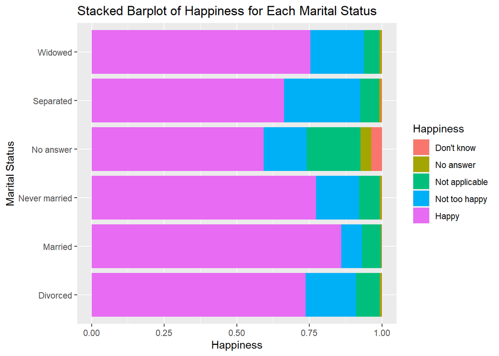

```r
# Graphical summary of the proportion of each responses in each marital status
happiness %>%
  ggplot(aes(x = married, fill = happiness)) +
  geom_bar(position = 'fill') +
  coord_flip() +
  ggtitle('Stacked Barplot of Happiness for Each Marital Status') +
  xlab('Marital Status') +
  ylab('Happiness') +
  labs(fill = "Happiness")
```

For this analysis, we used the variables “happiness” and “married”. We are defining that a person is happy if he/she answered either “Very happy” or “Pretty happy”. In the numerical summary, we are only taking into account the number of “Happy” responses (not considering how many people are in each marital status group). Based on the numerical summary, we can see that the group Married" has the highest number of happy people of 29342, which is followed by Never married, Divorced, Widowed, Separated, and No answer. The proportional aspects can be found in the graphical summary. The “Married” people show the highest proportion of the response “Happy”. Around 75% of the people the “Widowed”, “Divorced”, and “Never married” groups also responded that they are happy.

**4. Does party affiliation affect the relationship you found in the last question?**

```r
# Numerical summary of the number of people who responded "Happy" in each combination of marital status and party affiliation
happiness %>%
  filter(happiness == "Happy") %>%
  group_by(married, party) %>%
  summarise(count = n()) %>%
  arrange(desc(count)) %>%
  head(10)
```

```
## # A tibble: 10 x 3
## # Groups:   married [2]
##    married       party              count
##    <fct>         <fct>              <int>
##  1 Married       Not str democrat    5974
##  2 Married       Not str republican  5254
##  3 Married       Strong democrat     4146
##  4 Married       Independent         3933
##  5 Married       Strong republican   3407
##  6 Married       Ind,near dem        3203
##  7 Married       Ind,near rep        2826
##  8 Never married Not str democrat    2261
##  9 Never married Independent         1822
## 10 Never married Ind,near dem        1670
```

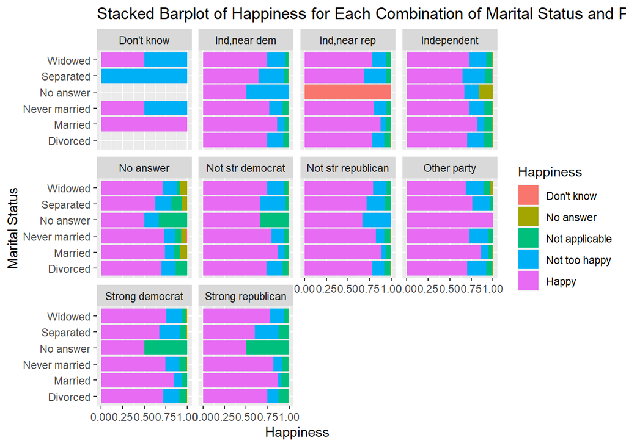

```r
# Graphical summary
happiness %>%
  ggplot(aes(x = married, fill = happiness)) +
  geom_bar(position = 'fill') +
  facet_wrap(~ party) +
  coord_flip() +
  ggtitle('Stacked Barplot of Happiness for Each Combination of Marital Status and Party Affiliation') +
  xlab('Marital Status') +
  ylab('Happiness') +
  labs(fill = "Happiness")
```

For this analysis, we used the variables “happiness”, “married”, and “party”.Except for the “Don’t know” group, the political party affiliation groups have very similar patterns. Except for the other party groups, the married people have the highest proportion of happy people while the no answer group has the lowest proportion of happy people. In other party group, the no answer group has the highest proportion of happy people. So party affiliation does not have a huge impact on the relationship between happiness and marital status.

**5. How is marital status related to the education of a respondent? What are possible reasons accounting for the patterns you see?**

```r
# Numerical summary of average years of education for each marital status
happiness3 = happiness %>%
  filter(edu %notin% c("No answer", "Don't know")) %>%
  group_by(married) %>%
  summarise(mean_edu = mean(as.numeric(edu))) %>%
  arrange(desc(mean_edu))
happiness3
```

```
## # A tibble: 6 x 2
##   married       mean_edu
##   <fct>            <dbl>
## 1 Widowed           9.65
## 2 No answer         9.30
## 3 Separated         8.25
## 4 Married           8.19
## 5 Divorced          7.85
## 6 Never married     7.60
```

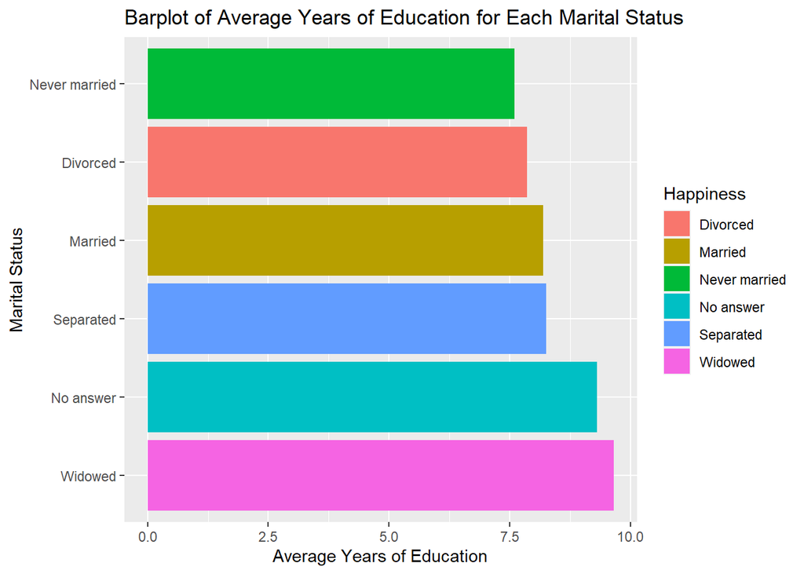

```r
# Graphical summary of average years of education for each marital status
happiness3 %>%
  ggplot(aes(x = reorder(married, -mean_edu), weight = mean_edu, fill = married)) +
  geom_bar() +
  coord_flip() +
  ggtitle('Barplot of Average Years of Education for Each Marital Status') +
  xlab('Marital Status') +
  ylab('Average Years of Education') +
  labs(fill = "Happiness")
```

**6. Explore two more interesting questions, and answer those questions using the GSS data.**

**6.1 How is the happiness of a respondent related to his/her total house income? Define that a person is happy if the response to question is “Very happy” or “Pretty happy”**

```r
# income
happiness$income = as.factor(happiness$income)
levels(happiness$income)
```

```
##  [1] "$1000 to 2999"  "$10000 - 14999" "$15000 - 19999" "$20000 - 24999"
##  [5] "$25000 or more" "$3000 to 3999"  "$4000 to 4999"  "$5000 to 5999"
##  [9] "$6000 to 6999"  "$7000 to 7999"  "$8000 to 9999"  "Don't know"
## [13] "Lt $1000"       "No answer"      "Not applicable" "Refused"
```

```r
# Numerical summary
happiness4 = happiness %>%
  filter(income %notin% c("Don't know", "No answer", "Not applicable", "Refused"),
         happiness == "Happy") %>%
  group_by(income) %>%
  summarise(count = n()) %>%
  arrange(desc(count))
happiness4
```

```
## # A tibble: 12 x 2
##    income         count
##    <fct>          <int>
##  1 $25000 or more 24210
##  2 $10000 - 14999  5261
##  3 $20000 - 24999  4255
##  4 $15000 - 19999  4140
##  5 $8000 to 9999   1695
##  6 $5000 to 5999   1004
##  7 $7000 to 7999    989
##  8 $1000 to 2999    965
##  9 $3000 to 3999    939
## 10 $6000 to 6999    921
## 11 $4000 to 4999    885
## 12 Lt $1000         510
```

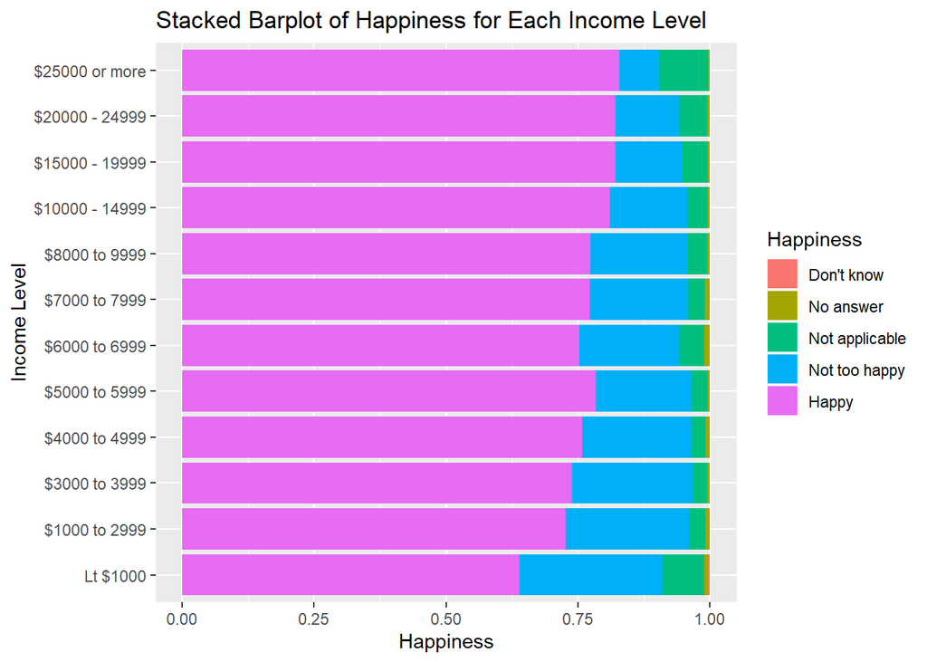

```r
##  Edits by jay.....
##  I fixed a few labeling issues on this graph.
##  it was listing marital status, not income level

# Graphical summary
happiness$income = factor(happiness$income, levels = c("Lt $1000",
                                                        "$1000 to 2999",
                                                        "$3000 to 3999",
                                                        "$4000 to 4999",
                                                        "$5000 to 5999",
                                                        "$6000 to 6999",
                                                        "$7000 to 7999",
                                                        "$8000 to 9999",
                                                        "$10000 - 14999",
                                                        "$15000 - 19999",
                                                        "$20000 - 24999",
                                                        "$25000 or more",
                                                        "Don't know",
                                                        "No answer",
                                                        "Not applicable",
                                                        "Refused"))

happiness %>%
  filter(income %notin% c("Don't know", "No answer", "Not applicable", "Refused")) %>%
  ggplot(aes(x = income, fill = happiness)) +
  geom_bar(position = 'fill') +
  coord_flip() +
  ggtitle('Stacked Barplot of Happiness for Each Income Level') +
  xlab('Income Level') +
  ylab('Happiness') +
  labs(fill = "Happiness")
```

**6.2 How is the happiness of a respondent related to gender? Define that a person is happy if the response to question is “Very happy” or “Pretty happy”**

```r
# gender
happiness$gender = as.factor(happiness$gender)
levels(happiness$gender)
```

```
## [1] "Female" "Male"
```

```r
# Numerical summary
happiness5 = happiness %>%
  filter(happiness == "Happy") %>%
  group_by(gender) %>%
  summarise(count = n()) %>%
  arrange(desc(count))
happiness5
```

```
## # A tibble: 2 x 2
##   gender count
##   <fct>  <int>
## 1 Female 29227
## 2 Male   23159
```

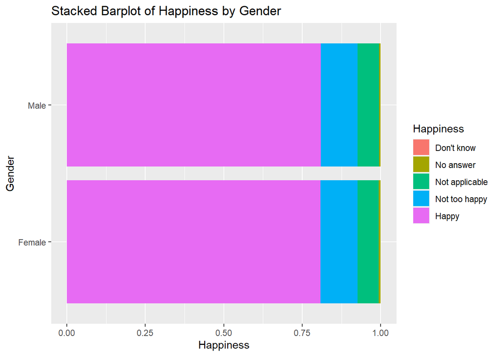

```r
# Graphical summary
happiness %>%
  ggplot(aes(x = gender, fill = happiness)) +
  geom_bar(position = 'fill') +
  coord_flip() +
  ggtitle('Stacked Barplot of Happiness by Gender') +
  xlab('Gender') +
  ylab('Happiness') +
  labs(fill = "Happiness")
```

## Conclusion

To conclude, even though it is hard to say that certain variables lead to more happiness or less happiness, people’s happiness status differ based on different variables. From the marital status analysis, we found that the Married group has the highest proportion of happy people while the Separated group has the lowest proportion of happy people (except for the No answer group). From the income analysis, we found that the higher the total family income is, the more likely they are to feel happy. Different from these variables, it was distinct that respondents’ gender does not affect their happiness.